# Assignment Outline

2024-10-24

1. What do you imagine is the reason for log-transforming the protein levels in biomarker-raw.csv? (Hint: look at the distribution of raw values for a sample of proteins.)

```r
# Loading packages
library(ggplot2)
library(readr)
library(dplyr)
library(reshape2)
library(tidyverse)
# Set seed for reproducibility
set.seed(123)

# Read in the data
biomarker_raw <- read_csv('biomarker-raw.csv', show_col_types=FALSE)
```

```r
# Subset all proteins in the dataset and convert to numeric values
proteins_numeric <- biomarker_raw %>% filter(Group %in% c("ASD", "TD")) %>%
  dplyr::select(contains("protein", ignore.case= TRUE)) %>%
  mutate(across(everything(), as.numeric))

# Randomly sample a vector of 10 protein names
random_sample <- sample(names(proteins_numeric), 10)
```

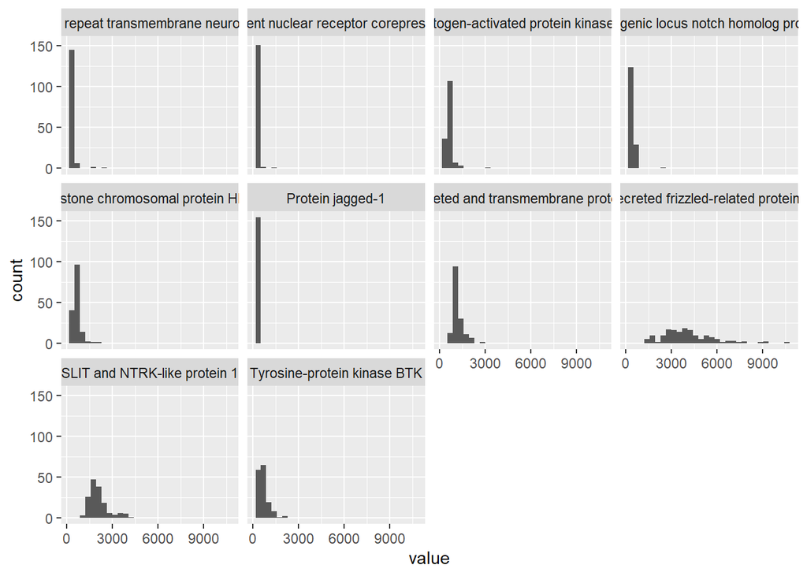

```r
# Looking at distribution of raw values for the random sample of proteins

# Plot 10 histograms; one histogram per randomly sampled protein
proteins_numeric %>%
  select(random_sample) %>%
  pivot_longer(everything()) %>%
  ggplot(aes(x = value)) + geom_histogram() +
  facet_wrap(vars(name))
```

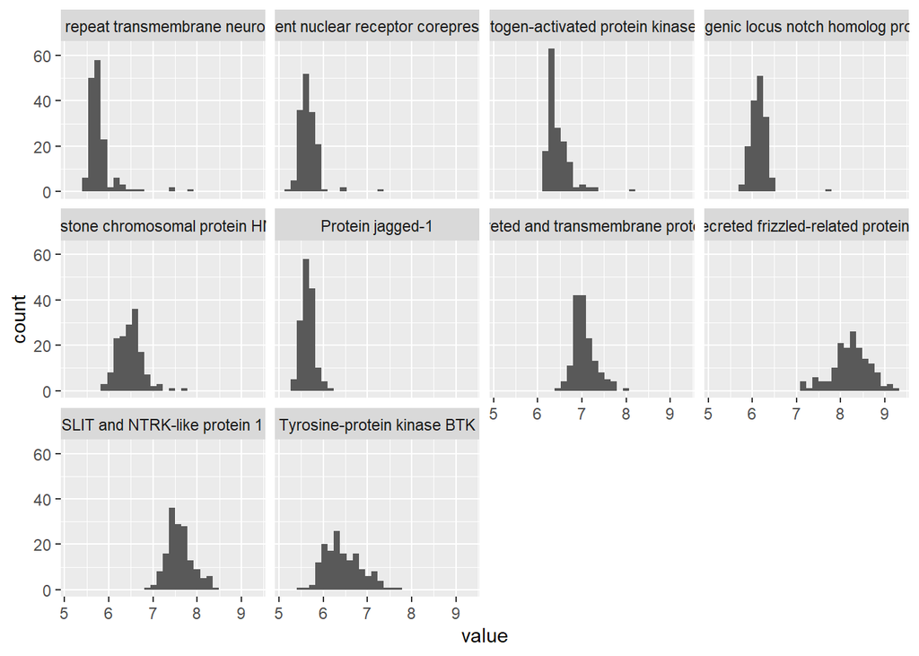

```r
# Looking at distribution of raw values for the random sample of proteins that are log-transformed

  # Log-transform all proteins
  proteins_numeric_log <- proteins_numeric %>%
    mutate(across(everything(), ~ log(. + 1)))

  # Plot 10 histograms; one histogram per randomly sampled protein

proteins_numeric_log %>%
  select(random_sample) %>%
  pivot_longer(everything()) %>%
  ggplot(aes(x = value)) + geom_histogram() +
  facet_wrap(vars(name))
```

2. Temporarily remove the outlier trimming from preprocessing and do some exploratory analysis of outlying values. Are there specific subjects (not values) that seem to be outliers? If so, are outliers more frequent in one group or the other? (Hint: consider tabluating the number of outlying values per subject.)

```r
library(tidyverse)


# get names
var_names <- read_csv('biomarker-raw.csv',
                      col_names = F,
                      n_max = 2,
                      col_select = -(1:2)) %>%
  t() %>%
  as_tibble() %>%
  rename(name = V1,
         abbreviation = V2) %>%
  na.omit()
# function for trimming outliers (good idea??)
trim <- function(x, .at){
  x[abs(x) > .at] <- sign(x[abs(x) > .at])*.at
  return(x)
}

# read in data
biomarker_clean <- read_csv('biomarker-raw.csv',
                            skip = 2,
                            col_select = -2L,
                            col_names = c('group',
                                          'empty',
                                          pull(var_names, abbreviation),
                                          'ados'),
                            na = c('-', '')) %>%
  filter(!is.na(group)) %>%
  # log transform, center and scale, and trim
  mutate(across(.cols = -c(group, ados),
                ~ trim(scale(log10(.x))[, 1], .at = 3))) %>%
  # reorder columns
  select(group, ados, everything())
library(dplyr)
temp <- biomarker_clean %>%
  filter(if_any(CHIP:PLXB2, ~ . ==3))

temp %>%
  count(group)
```

```
## # A tibble: 2 × 2
##   group     n
##   <chr> <int>
## 1 ASD      74
## 2 TD       77
```

```r
outlier_count <- temp %>%
  rowwise() %>%
  mutate(outliers = sum(c_across(CHIP:PLXB2) == 3)) %>%
  select(group, ados,outliers, everything())

outlier_count %>%
  group_by(group) %>%
  summarise(total_out = sum(outliers), avg_out = mean(outliers))
```

```
## # A tibble: 2 × 3
##   group total_out avg_out
##   <chr>     <int>   <dbl>
## 1 ASD         813    11.0
## 2 TD         1161    15.1
```

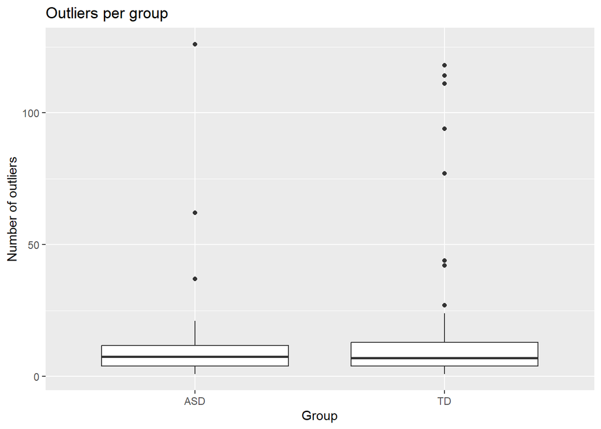

```r
outlier_count %>%
  ggplot(aes(x = group, y = outliers)) +
  geom_boxplot() +
  labs(title = 'Outliers per group',
       x = 'Group',
       y = 'Number of outliers')
```

```r
#About the same amount of people with at least one outlier in each group (ASD 74, TD 77)
#But TD have more individuals that have a higher amount of outliers (Boxplot)
#TD has a higher amount of total outliers as a group (ASD 813, TD 1161) and on average, an individual in TD would have more outliers (TD 15.1, ASD 11)
```

3. Experiment with the following modifications:
- repeat the analysis but carry out the entire selection procedure on a training partition – in other words, set aside some testing data at the very beginning and don’t use it until you are evaluating accuracy at the very end
- choose a larger number (more than ten) of top predictive proteins using each selection method
- use a fuzzy intersection instead of a hard intersection to combine the sets of top predictive proteins across selection methods

How are results affected by each modification?

4. Use any method to find either:
- a simpler panel that achieves comparable classification accuracy
- an alternative panel that achieves improved classification accuracy

Benchmark your results against the in-class analysis.